# Makes datafile of time stamped lapses

JJC and SJS

2021-03-01

## Set up paths and packages

```r
library(tidyverse)
library(janitor)
library(lubridate)
library(kableExtra)

source('P:/toolboxes/lab_support/fun_modeling.R')

path_data <- "P:/StudyData/RISK/analysis/shared/data"
path_notes <- "P:/StudyData/RISK/analysis/shared/notes"
path_raw <- "P:/StudyData/RISK/raw_data"
path_out <- "P:/StudyData/RISK/analysis/gps/data"
```

## Load files

Load, rename, and select for cleaned ema files

```r
ema_morning <- read_csv(file.path(path_data, 'ema_morning.csv'), col_types = cols()) %>%
  rename(ema_1 = emam_1,
         ema_1_1 = emam_1_1,
         ema_1_2 = emam_1_2,
         ema_1_3 = emam_1_3,
         ema_1_4 = emam_1_4,
         ema_1_5 = emam_1_5) %>%
  select(subid, response_id, start_date, end_date, utc, finished, starts_with("ema_1")) %>%
  mutate(type = "morning") %>%
  glimpse()
```

```
## Rows: 11,338
## Columns: 13
## $ subid       <chr> "001", "001", "001", "001", "001", "001", "001", "001",...
## $ response_id <chr> "R_1HkvSG8QkPx8Eu8", "R_2uBUNUJQQ1vkJwa", "R_2fy75pv8FO...
## $ start_date  <dttm> 2017-03-02 15:17:11, 2017-03-03 12:31:39, 2017-03-05 1...
## $ end_date    <dttm> 2017-03-02 15:20:19, 2017-03-03 12:35:33, 2017-03-05 1...
## $ utc         <dbl> 1488489431, 1488544299, 1488717171, 1488803446, 1488820...
## $ finished    <dbl> 1, 1, 1, 1, 1, 1, 1, 1, 1, 1, 1, 1, 1, 1, 1, 1, 1, 1, 1...
## $ ema_1       <chr> "No", "No", "No", "No", "No", "No", "No", "No", "No", "...
## $ ema_1_1     <chr> NA, NA, NA, NA, NA, NA, NA, NA, NA, NA, NA, NA, NA, NA,...
## $ ema_1_2     <chr> NA, NA, NA, NA, NA, NA, NA, NA, NA, NA, NA, NA, NA, NA,...
## $ ema_1_3     <chr> NA, NA, NA, NA, NA, NA, NA, NA, NA, NA, NA, NA, NA, NA,...
## $ ema_1_4     <chr> NA, NA, NA, NA, NA, NA, NA, NA, NA, NA, NA, NA, NA, NA,...
## $ ema_1_5     <chr> NA, NA, NA, NA, NA, NA, NA, NA, NA, NA, NA, NA, NA, NA,...
## $ type        <chr> "morning", "morning", "morning", "morning", "morning", ...
```

```r
ema_later <- read_csv(file.path(path_data, 'ema_later.csv'), col_types = cols()) %>%
  rename(ema_1 = emal_1,
         ema_1_1 = emal_1_1,
         ema_1_2 = emal_1_2,
         ema_1_3 = emal_1_3,
         ema_1_4 = emal_1_4,
         ema_1_5 = emal_1_5) %>%
  select(subid, response_id, start_date, end_date, utc, finished, starts_with("ema_1")) %>%
  mutate(type = "later") %>%
  glimpse()
```

```
## Rows: 34,138
## Columns: 13
## $ subid       <chr> "001", "001", "001", "001", "001", "001", "001", "001",...
## $ response_id <chr> "R_DCzfrTzvmKyStd7", "R_2dsYfdSOBQqnVZa", "R_2eXz8kIJqI...
## $ start_date  <dttm> 2017-03-02 20:27:53, 2017-03-03 03:00:38, 2017-03-03 1...
## $ end_date    <dttm> 2017-03-02 20:37:43, 2017-03-03 03:02:47, 2017-03-03 1...
## $ utc         <dbl> 1488486473, 1488510038, 1488550270, 1488631626, 1488645...
## $ finished    <dbl> 1, 1, 1, 1, 1, 1, 1, 1, 1, 1, 1, 1, 1, 1, 1, 1, 1, 1, 1...
## $ ema_1       <chr> "No", "No", "No", "No", "No", "No", "No", "No", "No", "...
## $ ema_1_1     <chr> NA, NA, NA, NA, NA, NA, NA, NA, NA, NA, NA, NA, NA, NA,...
## $ ema_1_2     <chr> NA, NA, NA, NA, NA, NA, NA, NA, NA, NA, NA, NA, NA, NA,...
## $ ema_1_3     <chr> NA, NA, NA, NA, NA, NA, NA, NA, NA, NA, NA, NA, NA, NA,...
## $ ema_1_4     <chr> NA, NA, NA, NA, NA, NA, NA, NA, NA, NA, NA, NA, NA, NA,...
## $ ema_1_5     <chr> NA, NA, NA, NA, NA, NA, NA, NA, NA, NA, NA, NA, NA, NA,...
## $ type        <chr> "later", "later", "later", "later", "later", "later", "...
```

```r
#Set TZ to america/chicago so it makes sense when comparing to lapse dates
ema <-
  ema_morning %>%
  bind_rows(ema_later) %>%
  mutate(start_date = force_tzs(time = start_date, tzones = "UTC", tzone_out = "America/Chicago"),
         end_date = force_tzs(time = end_date, tzones = "UTC", tzone_out = "America/Chicago")) %>%
  glimpse()
```

```
## Rows: 45,476
## Columns: 13
## $ subid       <chr> "001", "001", "001", "001", "001", "001", "001", "001",...
## $ response_id <chr> "R_1HkvSG8QkPx8Eu8", "R_2uBUNUJQQ1vkJwa", "R_2fy75pv8FO...
## $ start_date  <dttm> 2017-03-02 09:17:11, 2017-03-03 06:31:39, 2017-03-05 0...
## $ end_date    <dttm> 2017-03-02 09:20:19, 2017-03-03 06:35:33, 2017-03-05 0...
## $ utc         <dbl> 1488489431, 1488544299, 1488717171, 1488803446, 1488820...
## $ finished    <dbl> 1, 1, 1, 1, 1, 1, 1, 1, 1, 1, 1, 1, 1, 1, 1, 1, 1, 1, 1...
## $ ema_1       <chr> "No", "No", "No", "No", "No", "No", "No", "No", "No", "...
## $ ema_1_1     <chr> NA, NA, NA, NA, NA, NA, NA, NA, NA, NA, NA, NA, NA, NA,...
## $ ema_1_2     <chr> NA, NA, NA, NA, NA, NA, NA, NA, NA, NA, NA, NA, NA, NA,...
## $ ema_1_3     <chr> NA, NA, NA, NA, NA, NA, NA, NA, NA, NA, NA, NA, NA, NA,...
## $ ema_1_4     <chr> NA, NA, NA, NA, NA, NA, NA, NA, NA, NA, NA, NA, NA, NA,...
## $ ema_1_5     <chr> NA, NA, NA, NA, NA, NA, NA, NA, NA, NA, NA, NA, NA, NA,...
## $ type        <chr> "morning", "morning", "morning", "morning", "morning", ...
```

Open and combine data logs to look up notes about remaining problematic lapses

```r
log_morning <- read_csv(file.path(path_notes, "log_ema_morning.csv"), col_types = cols())

log_later <- read_csv(file.path(path_notes, "log_ema_later.csv"), col_types = cols())

log <- full_join(log_morning, log_later)
```

## Preliminary checks

ema_1 answered for all surveys. We will filter down to Yes below.

```r
ema %>% tabyl(ema_1)
```

```
##  ema_1     n    percent
##     No 44020 0.96798311
##    Yes  1456 0.03201689
```

```r
total_yes <- ema %>%
  tabyl(ema_1) %>%
  filter(ema_1 == "Yes") %>%
  pull(n)
```

### Reivew unfinished surveys

There are unfinished surveys

```r
ema %>% tabyl(finished)
```

```
##  finished     n    percent
##         0   724 0.01592049
##         1 44752 0.98407951
```

Some of these unfinished are lapse reports

```r
ema %>% tabyl(finished, ema_1)
```

```
##  finished    No  Yes
##         0   618  106
##         1 43402 1350
```

Here are those unfinished lapse reports

```r
ema %>%
  filter(finished == 0, ema_1 == "Yes") %>%
  select(starts_with("ema")) %>%
  print(n = Inf)
```

```
## # A tibble: 106 x 6
##     ema_1 ema_1_1    ema_1_2  ema_1_3    ema_1_4  ema_1_5
##     <chr> <chr>      <chr>    <chr>      <chr>    <chr>
##   1 Yes   <NA>       <NA>     <NA>       <NA>     <NA>
##   2 Yes   10-21-2017 1 AM     10-21-2017 1 AM     No
##   3 Yes   <NA>       <NA>     <NA>       <NA>     <NA>
##   4 Yes   02-05-2018 9 PM     02-05-2018 11 PM    Uncertain
##   5 Yes   <NA>       <NA>     <NA>       <NA>     <NA>
##   6 Yes   <NA>       <NA>     <NA>       <NA>     <NA>
##   7 Yes   <NA>       <NA>     <NA>       <NA>     <NA>
##   8 Yes   <NA>       <NA>     <NA>       <NA>     <NA>
##   9 Yes   08-01-2018 9 PM     08-01-2018 11 PM    Uncertain
##  10 Yes   08-07-2018 8 PM     08-07-2018 11 PM    Uncertain
##  11 Yes   <NA>       <NA>     <NA>       <NA>     <NA>
##  12 Yes   08-18-2018 <NA>     08-18-2018 <NA>     <NA>
```

[output cut: 94 more lines]

Many of the Yes responses have no dates, times or other info. This happened often when a participant incorrectly selected Yes and had no way to fix this. Surveys that are unfinished and didn’t at least include ema_1_1 (date of lapse) will be dropped.

```r
(removed_yes <- sum(ema$finished == 0 & ema$ema_1 == "Yes" & is.na(ema$ema_1_1)))
```

```
## [1] 76
```

However, unfinished responses that do include answers to question 1 follow-ups are retained

```r
ema_lapses <- ema %>%
  filter(!(finished == 0 & is.na(ema_1_1))) %>%
  filter(ema_1 == "Yes") %>%
  glimpse()
```

```
## Rows: 1,380
## Columns: 13
## $ subid       <chr> "003", "002", "002", "002", "003", "007", "007", "007",...
## $ response_id <chr> "R_spb5tgAORYYM0OR", "R_3oTRLcP1UfdS1bb", "R_6VFN7egqlw...
## $ start_date  <dttm> 2017-04-01 08:37:29, 2017-04-04 06:04:45, 2017-04-30 0...
## $ end_date    <dttm> 2017-04-01 08:38:40, 2017-04-04 06:05:37, 2017-04-30 0...
## $ utc         <dbl> 1491057449, 1491307485, 1493562787, 1494170279, 1495035...
## $ finished    <dbl> 1, 1, 1, 1, 1, 1, 1, 1, 1, 1, 1, 1, 1, 1, 1, 1, 1, 1, 1...
## $ ema_1       <chr> "Yes", "Yes", "Yes", "Yes", "Yes", "Yes", "Yes", "Yes",...
## $ ema_1_1     <chr> "03-31-2017", "04-03-2017", "04-29-2017", "05-06-2017",...
## $ ema_1_2     <chr> "10 PM", "6 PM", "8 PM", "8 PM", "9 PM", "Midnight", "1...
## $ ema_1_3     <chr> "03-31-2017", "04-03-2017", "04-29-2017", "05-06-2017",...
## $ ema_1_4     <chr> "10 PM", "9 PM", "10 PM", "9 PM", "9 PM", "1 AM", "1 AM...
## $ ema_1_5     <chr> "Yes", "Yes", "Yes", "Yes", "Yes", "Yes", "Yes", "Yes",...
## $ type        <chr> "morning", "morning", "morning", "morning", "morning", ...
```

Check my accounting of Yes responses

```r
nrow(ema_lapses) == total_yes - removed_yes
```

```
## [1] TRUE
```

### Check ema_lapses survey date stamps

No missing for start_date or end_date

```r
sum(is.na(ema_lapses$start_date))
```

```
## [1] 0
```

```r
sum(is.na(ema_lapses$end_date))
```

```
## [1] 0
```

One missing values for utc. There is one. It looks normal otherwise

```r
sum(is.na(ema_lapses$utc))
```

```
## [1] 1
```

```r
ema_lapses %>%
  filter(is.na(utc)) %>%
  print(n = Inf)
```

```
## # A tibble: 1 x 13
##   subid response_id start_date          end_date              utc finished ema_1
##   <chr> <chr>       <dttm>              <dttm>              <dbl>    <dbl> <chr>
## 1 131   R_3s0R3AKI~ 2018-12-15 20:35:14 2018-12-15 20:36:36    NA        1 Yes
## # ... with 6 more variables: ema_1_1 <chr>, ema_1_2 <chr>, ema_1_3 <chr>,
## #   ema_1_4 <chr>, ema_1_5 <chr>, type <chr>
```

#### Compare start_date to utc timestamp

Good except for responses that are off by an hour. Susan confirms this was an issue with piped in UTC stamp. We will not use utc

```r
ema_lapses %>%
  mutate(utc = as_datetime(utc, tz = "UTC", origin = "1970-01-01"),
         start_utc_diff_secs = as.numeric(difftime(start_date, utc, units = "secs"))) %>%
  pull(start_utc_diff_secs) %>%
  tabyl()
```

```
##      .   n      percent valid_percent
##  -3640   1 0.0007246377  0.0007251632
##  -3621   1 0.0007246377  0.0007251632
##  -3616   1 0.0007246377  0.0007251632
##  -3611   1 0.0007246377  0.0007251632
##  -3610   1 0.0007246377  0.0007251632
##  -3608   4 0.0028985507  0.0029006526
##  -3607   3 0.0021739130  0.0021754895
##  -3605   1 0.0007246377  0.0007251632
##  -3604   5 0.0036231884  0.0036258158
##  -3603   9 0.0065217391  0.0065264685
##  -3602   5 0.0036231884  0.0036258158
##  -3601 270 0.1956521739  0.1957940537
##  -3600 745 0.5398550725  0.5402465555
##    -21   1 0.0007246377  0.0007251632
##    -17   1 0.0007246377  0.0007251632
##     -7   1 0.0007246377  0.0007251632
##     -6   1 0.0007246377  0.0007251632
##     -4   3 0.0021739130  0.0021754895
##     -3   1 0.0007246377  0.0007251632
##     -2   4 0.0028985507  0.0029006526
##     -1  80 0.0579710145  0.0580130529
##      0 240 0.1739130435  0.1740391588
##     NA   1 0.0007246377            NA
```

```r
ema_lapses <- ema_lapses %>%
  select(-utc)
```

#### Compare start_date to end_date

- There are some surveys with VERY long completion times
- All will be retained

```r
ema_lapses <- ema_lapses %>%
  mutate(start_end_diff_mins = round(as.numeric(difftime(end_date, start_date, units = "mins")), 1))

ema_lapses %>% tabyl(start_end_diff_mins)
```

```
##  start_end_diff_mins   n      percent
##                  0.3   1 0.0007246377
##                  0.4   4 0.0028985507
##                  0.5  16 0.0115942029
##                  0.6  31 0.0224637681
##                  0.7  82 0.0594202899
##                  0.8 149 0.1079710145
##                  0.9 153 0.1108695652
##                  1.0 126 0.0913043478
##                  1.1 135 0.0978260870
##                  1.2 104 0.0753623188
##                  1.3  67 0.0485507246
##                  1.4  70 0.0507246377
##                  1.5  47 0.0340579710
##                  1.6  45 0.0326086957
##                  1.7  31 0.0224637681
##                  1.8  32 0.0231884058
##                  1.9  21 0.0152173913
##                  2.0  28 0.0202898551
##                  2.1  27 0.0195652174
##                  2.2  11 0.0079710145
##                  2.3  15 0.0108695652
##                  2.4  16 0.0115942029
##                  2.5  21 0.0152173913
##                  2.6  12 0.0086956522
##                  2.7   4 0.0028985507
##                  2.8  10 0.0072463768
##                  2.9   2 0.0014492754
##                  3.0  11 0.0079710145
##                  3.1   2 0.0014492754
##                  3.2   9 0.0065217391
##                  3.3   4 0.0028985507
##                  3.4   6 0.0043478261
##                  3.5   2 0.0014492754
##                  3.6   6 0.0043478261
##                  3.7   3 0.0021739130
##                  3.8   6 0.0043478261
##                  3.9   2 0.0014492754
##                  4.0   4 0.0028985507
##                  4.1   1 0.0007246377
```

[output cut: 29 more lines]

```
##                 18.9   1 0.0007246377
##                 25.6   1 0.0007246377
##                 26.6   1 0.0007246377
##                 31.1   1 0.0007246377
##                 31.6   1 0.0007246377
##                 32.7   1 0.0007246377
##                 39.8   1 0.0007246377
##                 42.8   1 0.0007246377
##                 57.6   1 0.0007246377
##                 60.1   1 0.0007246377
##                123.2   1 0.0007246377
##                147.5   1 0.0007246377
##                161.9   1 0.0007246377
##                582.4   1 0.0007246377
##               1454.3   1 0.0007246377
```

Here are the surveys with response times > 15 mins

```r
ema_lapses %>%
  filter(start_end_diff_mins > 15) %>%
  left_join(log) %>%
  select(start_end_diff_mins, subid, start_date, end_date, finished, contains("ema"), notes) %>%
  arrange(start_end_diff_mins) %>%
  print_kbl()
```

| start_end_diff_mins | subid | start_date | end_date | finished | ema_1 | ema_1_1 | ema_1_2 | ema_1_3 | ema_1_4 | ema_1_5 | notes |
| --- | --- | --- | --- | --- | --- | --- | --- | --- | --- | --- | --- |
| 17.4 | 056 | 2018-05-19 11:44:46 | 2018-05-19 12:02:10 | 1 | Yes | 05-18-2018 | 5 PM | 05-19-2018 | 3 AM | No | No audio messages or data notes to indicate long start_diff makes lapse report invalid - leave as is. |
| 18.9 | 039 | 2018-04-12 15:29:27 | 2018-04-12 15:48:18 | 1 | Yes | 04-12-2018 | Noon | 04-12-2018 | Noon | Uncertain | NA |
| 25.6 | 037 | 2018-03-24 17:43:29 | 2018-03-24 18:09:07 | 1 | Yes | 03-24-2018 | 3 PM | 03-24-2018 | 4 PM | Uncertain | Lutz lookup_tz() generated non America/Chicago timezone closest to lapse. Visually inspected and confirmed that new tz is accurate |
| 26.6 | 056 | 2018-07-07 12:22:13 | 2018-07-07 12:48:52 | 1 | Yes | 07-06-2018 | 7 PM | 07-07-2018 | 2 AM | Uncertain | No audio messages or data notes to indicate long start_diff makes lapse report invalid - leave as is. |
| 31.1 | 058 | 2018-07-09 20:43:37 | 2018-07-09 21:14:44 | 1 | Yes | 07-09-2018 | 5 PM | 07-09-2018 | 7 PM | Uncertain | NA |
| 31.6 | 128 | 2018-10-11 10:27:58 | 2018-10-11 10:59:32 | 1 | Yes | 10-11-2018 | 6 AM | 10-11-2018 | 10 AM | Yes | NA |
| 32.7 | 236 | 2019-08-13 10:28:51 | 2019-08-13 11:01:35 | 1 | Yes | 08-12-2019 | 8 PM | 08-12-2019 | 11 PM | Yes | No audio messages or data notes to indicate long start_diff makes lapse report invalid - leave as is. |
| 39.8 | 058 | 2018-06-19 20:31:02 | 2018-06-19 21:10:50 | 1 | Yes | 06-19-2018 | 7 PM | 06-19-2018 | 9 PM | Uncertain | NA |
| 42.8 | 058 | 2018-07-15 17:41:19 | 2018-07-15 18:24:07 | 1 | Yes | 07-15-2018 | 5 PM | 07-15-2018 | 9 PM | Uncertain | Lutz lookup_tz() generated non America/Chicago timezone closest to lapse. Visually inspected and confirmed that new tz is accurate |
| 57.6 | 037 | 2018-04-13 19:13:39 | 2018-04-13 20:11:15 | 1 | Yes | 04-13-2018 | 6 PM | 04-13-2018 | 8 PM | Uncertain | EMA open for 1 hr, no data in log or surrounding ema to suggest lapse is not accurate. Retain lapse as is |
| 60.1 | 026 | 2017-11-17 20:30:26 | 2017-11-17 21:30:31 | 1 | Yes | 11-17-2017 | 8 PM | 11-18-2017 | NA | Uncertain | 2/22/2018: At Follow up #1 RA learned that Participant 026 reported a lapse on 11/17/2017 at 8PM with first drink being on 11/17/2017 at 8PM and last drink on 11/04/2017 at 5AM. RA checked with the pa… |
| 60.1 | 026 | 2017-11-17 20:30:26 | 2017-11-17 21:30:31 | 1 | Yes | 11-17-2017 | 8 PM | 11-18-2017 | NA | Uncertain | Data log correction listed lapse end time that is later than time of EMA report. Therefore, true end time is unknown, setting to NA |
| 123.2 | 016 | 2017-10-06 20:01:44 | 2017-10-06 22:04:54 | 1 | Yes | 10-06-2017 | 7 PM | 10-06-2017 | 9 PM | Yes | EMA open for 2 hours, no data in log or surrounding ema to suggest lapse is not accurate. Retain lapse as is |
| 147.5 | 048 | 2018-05-30 04:52:46 | 2018-05-30 07:20:14 | 1 | Yes | 05-29-2018 | 6 PM | 05-30-2018 | 11 PM | Yes | EMA 5/30 from 4 - 7 am, lapse 5/29 6 pm to 5/30 11 pm (after report time). No audios or info in the data log. They did make a lapse entry for 5/29 from 6pm-10pm. This could be extending that drinking … |
| 161.9 | 098 | 2018-09-05 15:36:39 | 2018-09-05 18:18:35 | 1 | Yes | 09-05-2018 | 6 PM | 09-05-2018 | 6 PM | Yes | No info in data logs. Survey was open for a long time - while this lapse is ahead of the start time, it is before the end time so I trust this lapse report. Leave as is. |
| 582.4 | 150 | 2018-10-31 20:59:58 | 2018-11-01 06:42:19 | 1 | Yes | 10-31-2018 | 7 PM | 10-31-2018 | 7 PM | Uncertain | No data to suggest long distance from survey end is invalid |
| 1454.3 | 234 | 2019-08-28 21:10:30 | 2019-08-29 21:24:47 | 0 | Yes | 08-28-2019 | 9 PM | 08-28-2019 | 9 PM | Yes | Survey is unfinished, participant may have forgotten to submit and it automatically closed the next day. Reported lapse is within window and non-negative, so is retained as valid |

```r
ema_lapses <- ema_lapses %>%
  select(-start_end_diff_mins)
```

#### Create $lapse\_start$ and $lapse\_end$

First need to handle the coding of lapse hour variables

- Need to handle midnight as 12 am
- Need to handle noon as 12 pm

```r
ema_lapses %>% tabyl(ema_1_2)
```

```
##   ema_1_2   n      percent valid_percent
##      1 AM  22 0.0159420290  0.0159535896
##      1 PM  49 0.0355072464  0.0355329949
##     10 AM  42 0.0304347826  0.0304568528
##     10 PM  84 0.0608695652  0.0609137056
##     11 AM  42 0.0304347826  0.0304568528
##     11 PM  67 0.0485507246  0.0485859318
##      2 AM   6 0.0043478261  0.0043509790
##      2 PM  71 0.0514492754  0.0514865845
##      3 AM   3 0.0021739130  0.0021754895
##      3 PM  82 0.0594202899  0.0594633793
##      4 AM   3 0.0021739130  0.0021754895
##      4 PM  73 0.0528985507  0.0529369108
##      5 AM   1 0.0007246377  0.0007251632
##      5 PM 128 0.0927536232  0.0928208847
##      6 AM  10 0.0072463768  0.0072516316
##      6 PM 152 0.1101449275  0.1102248006
##      7 AM   2 0.0014492754  0.0014503263
##      7 PM 158 0.1144927536  0.1145757796
##      8 AM  13 0.0094202899  0.0094271211
##      8 PM 136 0.0985507246  0.0986221900
##      9 AM  16 0.0115942029  0.0116026106
##      9 PM 150 0.1086956522  0.1087744743
##  Midnight  11 0.0079710145  0.0079767948
##      Noon  58 0.0420289855  0.0420594634
##      <NA>   1 0.0007246377            NA
```

```r
ema_lapses <- ema_lapses %>%
  mutate(ema_1_2 = dplyr::recode(ema_1_2, Midnight = "12 AM", Noon = "12 PM"),
         ema_1_4 = dplyr::recode(ema_1_4, Midnight = "12 AM", Noon = "12 PM"))
```

Next, need to handle the time_zone issues. Sarah computed timezones for lapses (to be included as a separate script). Here was the process:

- Found the closest day with gps data to each lapse start date
- Used tz_lookup_coords from the lutz package to get the timezone of the closest gps day
- Lapses that occurred in a timezone other than America/Chicago, occurred on days where the participant was in more than one timezone, or did not have any gps data on the day of the reported lapse were added to the ema logs and were inspected with EDA to determine the timezone.
- All lapses in that were not in the america/chicago timezone are listed in the log, otherwise timezone is America/Chicago

Now, we need to:

1. Pull log entries that indicate new timezone

```r
recode_tz <- log %>%
  filter(log_action == "recode_tz") %>%
  select(response_id, new_value) %>%
  rename(time_zone = new_value) %>%
  glimpse()
```

```
## Rows: 55
## Columns: 2
## $ response_id <chr> "R_3n5jUclJJGizWVz", "R_3L6h57eLA0jFjs5", "R_325VMvwWMu...
## $ time_zone   <chr> "America/Detroit", "America/Detroit", "America/Detroit"...
```

2. Merge timezone info into ema_lapses tibble

```r
ema_lapses <- left_join(ema_lapses, recode_tz, by = "response_id") %>%
  mutate(time_zone = replace_na(time_zone, "America/Chicago"))
```

```r
ema_lapses %>% tabyl(time_zone)
```

```
##            time_zone    n     percent
##      America/Chicago 1325 0.960144928
##       America/Denver   11 0.007971014
##      America/Detroit    4 0.002898551
##  America/Los_Angeles    2 0.001449275
##     America/New_York   38 0.027536232
```

4. Now convert lapse time variables to $lapse\_start$ and $lapse\_end$

NOTE: There was 3 lapses with missing values for lapse onset hour and/or lapse offset hour. They remain missing for lapse_start and lapse_end.

```r
# make lapse start and end variables
ema_lapses <- ema_lapses %>%
  mutate(lapse_start = str_c(ema_1_1, ema_1_2, sep = " "),
         lapse_start = as_datetime(lapse_start, tz = "America/Chicago", format = "%m-%d-%Y %I %p"),
         lapse_start = force_tzs(time = lapse_start, tzones = time_zone, tzone_out = "America/Chicago"),
         lapse_end = str_c(ema_1_3, ema_1_4, sep = " "),
         lapse_end = as_datetime(lapse_end, tz = "America/Chicago", format = "%m-%d-%Y %I %p"),
         lapse_end = force_tzs(time = lapse_end, tzones = time_zone, tzone_out = "America/Chicago"))

ema_lapses %>%
  filter(is.na(lapse_start) | is.na(lapse_end)) %>%
  select(subid, response_id, contains("ema"), lapse_start, lapse_end, type) %>%
  print()
```

```
## # A tibble: 3 x 11
##   subid response_id ema_1 ema_1_1 ema_1_2 ema_1_3 ema_1_4 ema_1_5
##   <chr> <chr>       <chr> <chr>   <chr>   <chr>   <chr>   <chr>
## 1 081   R_cXU4FDBV~ Yes   08-18-~ <NA>    08-18-~ <NA>    <NA>
## 2 026   R_5jqOApLu~ Yes   11-17-~ 8 PM    11-18-~ <NA>    Uncert~
## 3 270   R_u2FmNGTy~ Yes   11-02-~ 1 PM    11-02-~ <NA>    Yes
## # ... with 3 more variables: lapse_start <dttm>, lapse_end <dttm>, type <chr>
```

#### Compare lapse_start to lapse_end

There are some clear issues to review here

- Some negative values
- Some really long values

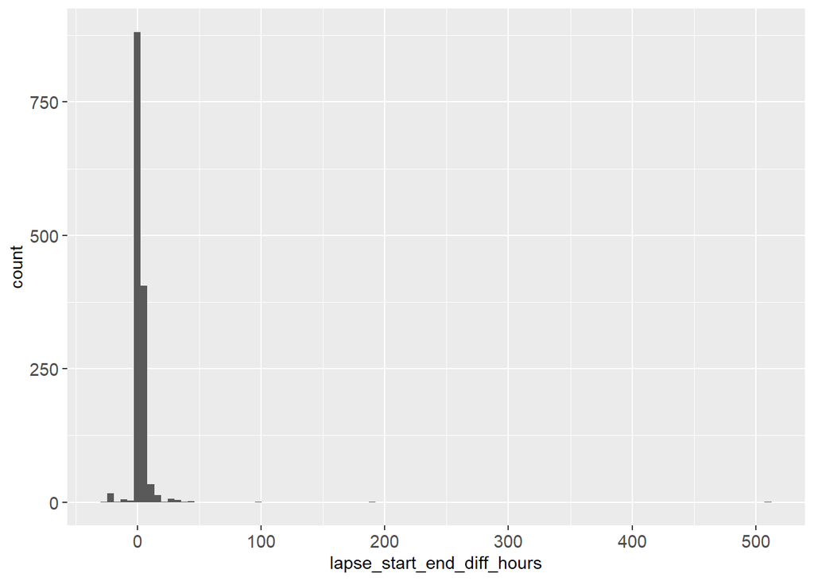

```r
ema_lapses <- ema_lapses %>%
  mutate(lapse_start_end_diff_hours = round(as.numeric(difftime(lapse_end, lapse_start, units = "hours")), 1))

ema_lapses %>% plot_hist("lapse_start_end_diff_hours")
```

Here are notes for negative and long positive lapses

```r
ema_lapses %>%
  filter(lapse_start_end_diff_hours < 0 | lapse_start_end_diff_hours > 15) %>%
  left_join(log) %>%
  select(lapse_start_end_diff_hours, subid, start_date, end_date, contains("ema"), lapse_start, lapse_end, notes) %>%
  arrange(lapse_start_end_diff_hours) %>%
  print_kbl()
```

| lapse_start_end_diff_hours | subid | start_date | end_date | ema_1 | ema_1_1 | ema_1_2 | ema_1_3 | ema_1_4 | ema_1_5 | lapse_start | lapse_end | notes |
| --- | --- | --- | --- | --- | --- | --- | --- | --- | --- | --- | --- | --- |
| -27 | 191 | 2019-05-26 18:59:48 | 2019-05-26 19:01:56 | Yes | 05-27-2019 | 10 PM | 05-26-2019 | 7 PM | Yes | 2019-05-27 22:00:00 | 2019-05-26 19:00:00 | EMA open from 2019-05-26 18 - 19, lapse reported as future 05-27-2019 at 10 PM- 05-26-2019 at 7 PM. M: Notes in data log are not super clear. Says lapse was fixed but no indication of how it should be… |
| -24 | 063 | 2018-06-26 18:19:35 | 2018-06-26 18:24:40 | Yes | 06-22-2018 | 12 PM | 06-21-2018 | 12 PM | Yes | 2018-06-22 12:00:00 | 2018-06-21 12:00:00 | No info in the datalogs or audio messages during this time. No surveys were completed between 6/20-6/26. Not any info to go on to decide what this needs to be. Leave as is, consider setting timestamps… |
| -23 | 043 | 2018-03-24 22:43:53 | 2018-03-24 22:45:10 | Yes | 03-24-2018 | 11 PM | 03-24-2018 | 12 AM | Uncertain | 2018-03-24 22:00:00 | 2018-03-23 23:00:00 | Lutz lookup_tz() generated non America/Chicago timezone closest to lapse. Visually inspected and confirmed that new tz is accurate |
| -23 | 189 | 2019-05-09 14:46:02 | 2019-05-09 14:50:38 | Yes | 05-09-2019 | 11 PM | 05-09-2019 | 12 AM | Yes | 2019-05-09 23:00:00 | 2019-05-09 00:00:00 | Report made on 5/9 at 14 reporting lapse later on 5/9 from 23 - 5/9 midnight (which is negative in time). Voice check in on 5/10 says “I drank a little yesterday” so we know a lapse occurred on 5/9. T… |
| -22 | 086 | 2018-08-30 23:27:21 | 2018-08-30 23:27:51 | Yes | 08-30-2018 | 10 PM | 08-30-2018 | 12 AM | Uncertain | 2018-08-30 22:00:00 | 2018-08-30 00:00:00 | Surrounding EMA indicated this is a typo associated with using midnight to mean on the same date. Updating end date to next day. Lapse end rounded up to slightly in future to capture full drinking win… |
| -22 | 104 | 2018-09-19 22:59:39 | 2018-09-19 23:01:05 | Yes | 09-19-2018 | 10 PM | 09-19-2018 | 12 AM | Uncertain | 2018-09-19 22:00:00 | 2018-09-19 00:00:00 | Surrounding EMA indicated this is a typo associated with using midnight to mean on the same date. Updating end date to next day. Lapse end rounded up to slightly in future to capture full drinking win… |
| -22 | 104 | 2018-10-02 23:01:41 | 2018-10-02 23:02:32 | Yes | 10-02-2018 | 10 PM | 10-02-2018 | 12 AM | Uncertain | 2018-10-02 22:00:00 | 2018-10-02 00:00:00 | Surrounding EMA indicated this is a typo associated with using midnight to mean on the same date. Updating end date to next day. Lapse end rounded up to slightly in future to capture full drinking win… |
| -22 | 104 | 2018-10-03 22:59:27 | 2018-10-03 23:00:09 | Yes | 10-03-2018 | 10 PM | 10-03-2018 | 12 AM | Uncertain | 2018-10-03 22:00:00 | 2018-10-03 00:00:00 | Surrounding EMA indicated this is a typo associated with using midnight to mean on the same date. Updating end date to next day. Lapse end rounded up to slightly in future to capture full drinking win… |
| -21 | 104 | 2018-09-25 23:01:48 | 2018-09-25 23:02:35 | Yes | 09-25-2018 | 9 PM | 09-25-2018 | 12 AM | Uncertain | 2018-09-25 21:00:00 | 2018-09-25 00:00:00 | Surrounding EMA indicated this is a typo associated with using midnight to mean on the same date. Updating end date to next day. Lapse end rounded up to slightly in future to capture full drinking win… |
| -21 | 104 | 2018-09-28 23:55:06 | 2018-09-28 23:55:45 | Yes | 09-28-2018 | 9 PM | 09-28-2018 | 12 AM | Uncertain | 2018-09-28 21:00:00 | 2018-09-28 00:00:00 | Surrounding EMA indicated this is a typo associated with using midnight to mean on the same date. Updating end date to next day. Lapse end rounded up to slightly in future to capture full drinking win… |
| -21 | 104 | 2018-10-01 23:08:11 | 2018-10-01 23:08:49 | Yes | 10-01-2018 | 9 PM | 10-01-2018 | 12 AM | Uncertain | 2018-10-01 21:00:00 | 2018-10-01 00:00:00 | Surrounding EMA indicated this is a typo associated with using midnight to mean on the same date. Updating end date to next day. Lapse end rounded up to slightly in future to capture full drinking win… |
| -21 | 104 | 2018-10-06 23:00:26 | 2018-10-06 23:01:09 | Yes | 10-06-2018 | 9 PM | 10-06-2018 | 12 AM | Uncertain | 2018-10-06 21:00:00 | 2018-10-06 00:00:00 | Surrounding EMA indicated this is a typo associated with using midnight to mean on the same date. Updating end date to next day. Lapse end rounded up to slightly in future to capture full drinking win… |
| -21 | 104 | 2018-10-08 23:02:21 | 2018-10-08 23:03:22 | Yes | 10-08-2018 | 9 PM | 10-08-2018 | 12 AM | Uncertain | 2018-10-08 21:00:00 | 2018-10-08 00:00:00 | Surrounding EMA indicated this is a typo associated with using midnight to mean on the same date. Updating end date to next day. Lapse end rounded up to slightly in future to capture full drinking win… |
| -21 | 104 | 2018-10-22 23:28:29 | 2018-10-22 23:30:42 | Yes | 10-22-2018 | 9 PM | 10-22-2018 | 12 AM | Uncertain | 2018-10-22 21:00:00 | 2018-10-22 00:00:00 | Surrounding EMA indicated this is a typo associated with using midnight to mean on the same date. Updating end date to next day. Lapse end rounded up to slightly in future to capture full drinking win… |
| -20 | 104 | 2018-09-27 23:02:21 | 2018-09-27 23:03:26 | Yes | 09-27-2018 | 8 PM | 09-27-2018 | 12 AM | Uncertain | 2018-09-27 20:00:00 | 2018-09-27 00:00:00 | Surrounding EMA indicated this is a typo associated with using midnight to mean on the same date. Updating end date to next day. Lapse end rounded up to slightly in future to capture full drinking win… |
| -19 | 104 | 2018-09-23 23:38:15 | 2018-09-23 23:39:15 | Yes | 09-23-2018 | 7 PM | 09-23-2018 | 12 AM | Uncertain | 2018-09-23 19:00:00 | 2018-09-23 00:00:00 | Surrounding EMA indicated this is a typo associated with using midnight to mean on the same date. Updating end date to next day. Lapse end rounded up to slightly in future to capture full drinking win… |
| -19 | 212 | 2019-04-16 22:00:19 | 2019-04-16 22:02:37 | Yes | 04-16-2019 | 9 PM | 04-16-2019 | 2 AM | Yes | 2019-04-16 21:00:00 | 2019-04-16 02:00:00 | EMA open 4/16 at 22, reporting a negative lapse (4/16 9 pm to 4/16 at 2 am). No info to suggest when drinking ended, leve as is. Consider changing end time to na in processing. |
| -18 | 056 | 2018-04-20 18:27:46 | 2018-04-20 18:30:33 | Yes | 04-20-2018 | 6 PM | 04-20-2018 | 12 AM | Uncertain | 2018-04-20 18:00:00 | 2018-04-20 00:00:00 | Surrounding lapse and voice report support lapse on 4-20, but end time of midnight is impossible with 6 pm EMA report. No notes to suggest what the end time should be changed to. Consider setting end … |
| -12 | 056 | 2018-06-25 14:44:10 | 2018-06-25 14:45:51 | Yes | 06-24-2018 | 1 PM | 06-24-2018 | 1 AM | Uncertain | 2018-06-24 13:00:00 | 2018-06-24 01:00:00 | No audio or data logs to suggest time changes. Subject drinking frequently these days supporting this long lapse, but unable to tell if they meant 1 am to 1 pm or 1 pm to one am. Leave as is and consi… |
| -12 | 086 | 2018-10-14 12:14:37 | 2018-10-14 12:15:25 | Yes | 10-13-2018 | 12 PM | 10-13-2018 | 12 AM | Uncertain | 2018-10-13 12:00:00 | 2018-10-13 00:00:00 | report 10-14 at noon of 10-13 lapse noon to 12-13 midnight (negative lapse). Audio on 10/13 at 5 pm says they ran into a lot of risky situations today, more based on circumstance, said he drank becaus… |
| -12 | 017 | 2017-11-04 13:55:57 | 2017-11-04 13:57:05 | Yes | 11-05-2017 | 12 AM | 11-04-2017 | 12 PM | Yes | 2017-11-05 00:00:00 | 2017-11-04 12:00:00 | Surrounding EMA suggest start date type due to midnight more likely than full day lapse. Updating start date to same day |
| -11 | 056 | 2018-06-17 19:07:14 | 2018-06-17 19:08:22 | Yes | 06-17-2018 | 1 PM | 06-17-2018 | 2 AM | Uncertain | 2018-06-17 13:00:00 | 2018-06-17 02:00:00 | No explicit info in data logs or audios. Their previous lapse reported a lapse from 6/15 20 - 6/16 at 2 am. That report was at 15:53 on 6/16, so its not unusual for them to report previous night drink… |
| -9 | 086 | 2018-09-16 12:35:36 | 2018-09-16 12:36:08 | Yes | 09-16-2018 | 10 AM | 09-16-2018 | 1 AM | Uncertain | 2018-09-16 10:00:00 | 2018-09-16 01:00:00 | Report 9-16 noon, lapse future 9-22 10 am to 9-16 1 am. No info in data logs. No info in the audio messages that indicate a lapse on 9/16. Lots of EMAs that answer no during this time period suggest t… |
| -6 | 077 | 2018-08-12 11:43:18 | 2018-08-12 11:46:21 | Yes | 08-12-2018 | 5 PM | 08-12-2018 | 11 AM | Yes | 2018-08-12 17:00:00 | 2018-08-12 11:00:00 | Report open on 8/12 11:45 am Reported lapse of 8/12 17 (future) to 8/12 11 am. No evidence to support what true start time could be (mabe 5 am?), leaving as is, consider setting start time to NA |
| -4 | 180 | 2019-03-03 19:29:48 | 2019-03-03 19:31:34 | Yes | 03-03-2019 | 4 PM | 03-03-2019 | 12 PM | Uncertain | 2019-03-03 16:00:00 | 2019-03-03 12:00:00 | Report open 03-03 19:29, lapse at 03-03-2019 at 16 - 03-05-2019 at 12. Lapse end is later than survey completion. 3/4 audio at 7 AM says she got back from vacation yesterday and drank every day but is… |
| -4 | 191 | 2019-03-22 19:26:10 | 2019-03-22 19:28:29 | Yes | 03-22-2019 | 11 PM | 03-22-2019 | 7 PM | Yes | 2019-03-22 23:00:00 | 2019-03-22 19:00:00 | Survey open 3/22 at 19 to 3:23 00:30 am, lapse reported at 3-22 at 3 to “7pm” at 19. 7 pm is a typo in place of the date – makes most sense to correct to date to 3/22? No audios to confirm but other e… |
| -2 | 017 | 2017-11-06 08:00:08 | 2017-11-06 08:01:10 | Yes | 11-06-2017 | 10 AM | 11-06-2017 | 8 AM | Yes | 2017-11-06 10:00:00 | 2017-11-06 08:00:00 | EMA 11/6 at 8 AM reports a negative lapse starting in the future 11-6 10:00 AM - 11-6 8 AM. This could indicate drinking either the night before or today – no data to inform what possible correction t… |
| -2 | 053 | 2018-05-14 20:05:33 | 2018-05-14 20:09:21 | Yes | 05-14-2018 | 6 PM | 05-14-2018 | 4 PM | Yes | 2018-05-14 18:00:00 | 2018-05-14 16:00:00 | Seems more than likely that sub was intoxicated when they completed this survey. Her audio messages are very alarming. Possible that she made a typo, but not sure how much we can trust this report. Fl… |
| -2 | 081 | 2018-08-15 19:15:35 | 2018-08-15 19:17:04 | Yes | 08-15-2018 | 5 PM | 08-15-2018 | 3 PM | Yes | 2018-08-15 17:00:00 | 2018-08-15 15:00:00 | 081- 09/05/2018: RA reviewed the incomplete/”false” surveys with the participant if yes was recorded for EMAL_1.The participant reported a response of “yes” to EMAL_1 on the following surveys: UTC: 15… |
| -1 | 098 | 2018-09-18 21:05:09 | 2018-09-18 21:05:59 | Yes | 09-18-2018 | 7 PM | 09-18-2018 | 6 PM | Yes | 2018-09-18 19:00:00 | 2018-09-18 18:00:00 | No info in data logs. Possibly just reverse these. NO info in audio messages to clear this up. Reverse is most logical but no data to support. Leave as is |
| 16 | 185 | 2019-04-14 07:38:26 | 2019-04-14 07:40:26 | Yes | 04-12-2019 | 4 PM | 04-13-2019 | 8 AM | Yes | 2019-04-12 16:00:00 | 2019-04-13 08:00:00 | Report 4-14 7:30 am, lapse 4-12 4 pm - 4/12 8 am (negative). Sub reported in an audio message on 4/20 that he was upset about last Friday (4/12) when he found out his girlfriend cheated on him. This s… |
| 16 | 128 | 2018-09-26 14:15:49 | 2018-09-26 14:17:03 | Yes | 09-25-2018 | 10 PM | 09-26-2018 | 2 PM | Yes | 2018-09-25 22:00:00 | 2018-09-26 14:00:00 | This long lapse occurs in chain of longer lapses, making long lapse seem more liekly - there are no ema or audio data indicating otherwise. No changes recommended |
| 17 | 104 | 2018-08-26 22:37:41 | 2018-08-26 22:39:29 | Yes | 08-26-2018 | 6 AM | 08-26-2018 | 11 PM | Yes | 2018-08-26 06:00:00 | 2018-08-26 23:00:00 | No info in data logs. No info in audio messages either. This was reported again as it was the night before. Indicates that they might definitely be intoxicated at the time of survey. completion. The f… |
| 17 | 104 | 2018-08-26 23:00:16 | 2018-08-26 23:01:29 | Yes | 08-26-2018 | 6 AM | 08-26-2018 | 11 PM | Yes | 2018-08-26 06:00:00 | 2018-08-26 23:00:00 | Duplicate report of previous lapse. No info in data logs. No info in audio messages either. This was reported again as it was the night before. Indicates that they might definitely be intoxicated at t… |
| 17 | 221 | 2019-06-08 14:41:13 | 2019-06-08 14:46:25 | Yes | 06-07-2019 | 9 PM | 06-08-2019 | 2 PM | Uncertain | 2019-06-07 21:00:00 | 2019-06-08 14:00:00 | Sub reported quite a few longer lapses during participation. No audios or notes in data log regarding this time. No emas were completed during the alleged lapse window lending support for this. I do n… |
| 18 | 048 | 2018-06-02 11:36:23 | 2018-06-02 11:37:15 | Yes | 06-01-2018 | 5 PM | 06-02-2018 | 11 AM | Yes | 2018-06-01 17:00:00 | 2018-06-02 11:00:00 | Sub mentioned in audio on 6/2 that he drank a little before work, but doesn’t indicate heavy drinking. All June 1st emas reported no drinking and this lapse report is the only one for 6/2 S: Agree, he… |
| 18 | 221 | 2019-06-09 16:14:05 | 2019-06-09 16:14:51 | Yes | 06-08-2019 | 10 PM | 06-09-2019 | 4 PM | Uncertain | 2019-06-08 22:00:00 | 2019-06-09 16:00:00 | Survey completed on 6/9 at 16, reporting lapse from 06-08-2019 at 22 to 06-10-2019 at 16. Lapse end time is later than survey completion. 6/11 audio says “I’m two days sober” supporting changing lapse… |
| 19 | 221 | 2019-06-14 13:41:18 | 2019-06-14 13:42:01 | Yes | 06-13-2019 | 3 PM | 06-14-2019 | 10 AM | Yes | 2019-06-13 15:00:00 | 2019-06-14 10:00:00 | EMA 6/14 at 13 reporting lapse 6/13 at 15 to 6/15 at 10. Lapse end time is after ema completion, likely a date typo. In her audio message on 06/16 she reported that she is on day 2 of sobriety meaning… |
| 25 | 128 | 2018-11-17 10:54:34 | 2018-11-17 10:55:42 | Yes | 11-16-2018 | 10 AM | 11-17-2018 | 11 AM | Yes | 2018-11-16 10:00:00 | 2018-11-17 11:00:00 | Seems credible - audio 11/16 details an incredibly stressful day long situation, and audio on 11/17 indicates that she has not been fighting the urge to drink. long lapse and report length seem credib… |
| 26 | 180 | 2019-04-28 06:29:36 | 2019-04-28 06:30:39 | Yes | 04-27-2019 | 4 PM | 04-28-2019 | 6 PM | Uncertain | 2019-04-27 15:00:00 | 2019-04-28 17:00:00 | Lutz lookup_tz() generated non America/Chicago timezone closest to lapse. Visually inspected and confirmed that new tz is accurate |
| 27 | 010 | 2017-08-27 12:23:16 | 2017-08-27 12:24:44 | Yes | 08-24-2017 | 6 PM | 08-25-2017 | 9 PM | Yes | 2017-08-24 18:00:00 | 2017-08-25 21:00:00 | No notes in audio, individial or full data log, or indication from EMAs.Missed all EMAs across these dates. Nothing to suggest we should change even though its a long lapse |
| 28 | 267 | 2019-09-27 13:43:32 | 2019-09-27 13:44:20 | Yes | 09-26-2019 | 6 PM | 09-27-2019 | 10 PM | Uncertain | 2019-09-26 18:00:00 | 2019-09-27 22:00:00 | No voice reports or data log entries to suggest possible fix for lapse end reports 8 hours after survey completion. Most logical is lapse end is a typo for 9-26, but no data to confirm. Consider setti… |
| 29 | 043 | 2018-04-22 15:45:30 | 2018-04-22 15:46:21 | Yes | 04-21-2018 | 10 AM | 04-22-2018 | 3 PM | Uncertain | 2018-04-21 10:00:00 | 2018-04-22 15:00:00 | No info in the data logs. Audio message says they were at an alumni function for several days and said it was wild and they need to now focus on sobriety. Two reports on 4/22 said they had no drinking… |
| 29 | 048 | 2018-05-30 04:52:46 | 2018-05-30 07:20:14 | Yes | 05-29-2018 | 6 PM | 05-30-2018 | 11 PM | Yes | 2018-05-29 18:00:00 | 2018-05-30 23:00:00 | EMA 5/30 from 4 - 7 am, lapse 5/29 6 pm to 5/30 11 pm (after report time). No audios or info in the data log. They did make a lapse entry for 5/29 from 6pm-10pm. This could be extending that drinking … |
| 32 | 221 | 2019-06-21 21:00:38 | 2019-06-21 21:01:26 | Yes | 06-20-2019 | 3 PM | 06-21-2019 | 11 PM | Yes | 2019-06-20 15:00:00 | 2019-06-21 23:00:00 | Survey completed 6/21 at 11 pm, lapse reported as 6/20 at 3pm - 6/21 at 11pm. Audio on 6.24 reports being “5 days sober” which does not align with lapse start or end time, but possible she was countin… |
| 33 | 043 | 2018-05-29 10:11:29 | 2018-05-29 10:13:42 | Yes | 05-27-2018 | 11 AM | 05-28-2018 | 8 PM | No | 2018-05-27 11:00:00 | 2018-05-28 20:00:00 | No info in the data logs and no audios were completed around this time. 1 EMA was completed on 5/27 recording a different lapse and none were completed on 5/28. No other reports were completed prior t… |
| 34 | 048 | 2018-05-27 10:23:43 | 2018-05-27 10:25:01 | Yes | 05-25-2018 | 2 PM | 05-27-2018 | 12 AM | Yes | 2018-05-25 14:00:00 | 2018-05-27 00:00:00 | Report 5/27 10 am, lapse 5/25 2 pm to 5-27 12 am. No audio messages between 5/25-6/01. No information in data logs - no changes |
| 35 | 105 | 2018-09-03 14:31:02 | 2018-09-03 14:31:54 | Yes | 09-02-2018 | 12 PM | 09-03-2018 | 11 PM | Yes | 2018-09-02 12:00:00 | 2018-09-03 23:00:00 | No info in data logs or audio messages. Long lapses are not uncommon for this participant, but lapse end is 8 hours after survey completion. Consider setting lapse times to NA in processing |
| 39 | 053 | 2018-05-15 14:40:45 | 2018-05-15 14:42:03 | Yes | 05-14-2018 | 1 AM | 05-15-2018 | 4 PM | Yes | 2018-05-14 01:00:00 | 2018-05-15 16:00:00 | The audio message made on 5/15 the sub reported that they were very very drunk and needed help and were going to go into rehab in a couple days so this long lapse seems feasible. End time is after sur… |
| 43 | 080 | 2018-08-05 19:33:32 | 2018-08-05 19:34:57 | Yes | 08-03-2018 | 9 PM | 08-05-2018 | 4 PM | Yes | 2018-08-03 21:00:00 | 2018-08-05 16:00:00 | Report open 8/5 at 19:30 Reported lapse from 8/3 21 to 8/5 16. No emas at all on 8/3, but 2 emas on 8/4 and 8/5 that report no use making a 2 day lapse seem unlikely, but no indication of better end t… |
| 44 | 093 | 2018-08-09 15:54:32 | 2018-08-09 15:55:37 | Yes | 08-07-2018 | 8 PM | 08-09-2018 | 4 PM | Uncertain | 2018-08-07 20:00:00 | 2018-08-09 16:00:00 | No info in data logs. No audio messages during this time. No surveys were completed in between this lapse. No changes possible |
| 98 | 059 | 2018-07-16 19:55:09 | 2018-07-16 19:56:09 | Yes | 07-12-2018 | 8 AM | 07-16-2018 | 10 AM | Yes | 2018-07-12 08:00:00 | 2018-07-16 10:00:00 | Keep long report: no emas or audio between 7/12 and this date to suggest changes |
| 188 | 213 | 2019-05-21 17:46:48 | 2019-05-21 17:47:58 | Yes | 05-13-2019 | 9 PM | 05-21-2019 | 5 PM | Uncertain | 2019-05-13 21:00:00 | 2019-05-21 17:00:00 | from data log: - “UTC: 1558482409. Participant reported having drank alcohol nearly every day during the lapse dates provided. They reported the first day, 05/13/2019 being the heaviest day, and the s… |
| 510 | 116 | 2018-11-22 22:05:02 | 2018-11-22 22:07:29 | Yes | 11-01-2018 | 5 PM | 11-22-2018 | 10 PM | Yes | 2018-11-01 17:00:00 | 2018-11-22 22:00:00 | Report 11/22 22:05 - 21 day lapse from 11/1 at 17 to 11/22 at 22. Sub only completed 2 other emas between 11/1 and 11/22, and they were both 10 hr lapses. Its not impossible that this person was lapsi… |

```r
ema_lapses <- ema_lapses %>%
  select(-lapse_start_end_diff_hours)
```

#### Compare lapse start date to survey start date

Here is a comparison of the lapse start time to the survey start time. Lapse starts should have preceded survey starts unless

- It was a survey that was started and left open to be finished after the lapse
- It was an error

```r
ema_lapses <- ema_lapses %>%
  mutate(survey_lapse_diff_start_hours = round(as.numeric(difftime(start_date, lapse_start, units = "hours")), 1))
```

```r
ema_lapses %>%
  filter(survey_lapse_diff_start_hours < 0 | survey_lapse_diff_start_hours > 24) %>%
  left_join(log) %>%
  select(survey_lapse_diff_start_hours, subid, start_date, end_date, contains("ema"), lapse_start, lapse_end, notes) %>%
  arrange(survey_lapse_diff_start_hours) %>%
  print_kbl()
```

| survey_lapse_diff_start_hours | subid | start_date | end_date | ema_1 | ema_1_1 | ema_1_2 | ema_1_3 | ema_1_4 | ema_1_5 | lapse_start | lapse_end | notes |
| --- | --- | --- | --- | --- | --- | --- | --- | --- | --- | --- | --- | --- |
| -27.0 | 191 | 2019-05-26 18:59:48 | 2019-05-26 19:01:56 | Yes | 05-27-2019 | 10 PM | 05-26-2019 | 7 PM | Yes | 2019-05-27 22:00:00 | 2019-05-26 19:00:00 | EMA open from 2019-05-26 18 - 19, lapse reported as future 05-27-2019 at 10 PM- 05-26-2019 at 7 PM. M: Notes in data log are not super clear. Says lapse was fixed but no indication of how it should be… |
| -16.4 | 034 | 2017-12-16 08:33:30 | 2017-12-16 08:35:08 | Yes | 12-17-2017 | 1 AM | 12-17-2017 | 2 AM | Yes | 2017-12-17 01:00:00 | 2017-12-17 02:00:00 | 8 am report on 12-16 for lapse 1-2 am 12-17. Seems like a typo but not enough evidence to support change. No clear audios discussing a specific lapse just that they have been super stressed with final… |
| -10.1 | 017 | 2017-11-04 13:55:57 | 2017-11-04 13:57:05 | Yes | 11-05-2017 | 12 AM | 11-04-2017 | 12 PM | Yes | 2017-11-05 00:00:00 | 2017-11-04 12:00:00 | Surrounding EMA suggest start date type due to midnight more likely than full day lapse. Updating start date to same day |
| -9.7 | 039 | 2018-04-15 10:17:23 | 2018-04-15 10:19:34 | Yes | 04-15-2018 | 8 PM | 04-15-2018 | 9 PM | Yes | 2018-04-15 20:00:00 | 2018-04-15 21:00:00 | 4-15 10 am reporting future lapse 5-18 9 pm - 9 pm. No audio messages during this time, nothing in data logs. Possible typo for 4/14. There was one other ema where this could have been reported, but a… |
| -8.2 | 189 | 2019-05-09 14:46:02 | 2019-05-09 14:50:38 | Yes | 05-09-2019 | 11 PM | 05-09-2019 | 12 AM | Yes | 2019-05-09 23:00:00 | 2019-05-09 00:00:00 | Report made on 5/9 at 14 reporting lapse later on 5/9 from 23 - 5/9 midnight (which is negative in time). Voice check in on 5/10 says “I drank a little yesterday” so we know a lapse occurred on 5/9. T… |
| -5.3 | 077 | 2018-08-12 11:43:18 | 2018-08-12 11:46:21 | Yes | 08-12-2018 | 5 PM | 08-12-2018 | 11 AM | Yes | 2018-08-12 17:00:00 | 2018-08-12 11:00:00 | Report open on 8/12 11:45 am Reported lapse of 8/12 17 (future) to 8/12 11 am. No evidence to support what true start time could be (mabe 5 am?), leaving as is, consider setting start time to NA |
| -3.6 | 191 | 2019-03-22 19:26:10 | 2019-03-22 19:28:29 | Yes | 03-22-2019 | 11 PM | 03-22-2019 | 7 PM | Yes | 2019-03-22 23:00:00 | 2019-03-22 19:00:00 | Survey open 3/22 at 19 to 3:23 00:30 am, lapse reported at 3-22 at 3 to “7pm” at 19. 7 pm is a typo in place of the date – makes most sense to correct to date to 3/22? No audios to confirm but other e… |
| -2.5 | 189 | 2019-05-19 13:31:35 | 2019-05-19 13:34:13 | Yes | 05-19-2019 | 4 PM | 05-19-2019 | 11 PM | Yes | 2019-05-19 16:00:00 | 2019-05-19 23:00:00 | This survey was completed 10 seconds before the survey right after it (resp ID R_vHR0jiGhMl5EFQR). This survey reports a lapse on 5-19 16 - 23, the other says 5/20 10-13, and a third ema report on 5/2… |
| -2.4 | 098 | 2018-09-05 15:36:39 | 2018-09-05 18:18:35 | Yes | 09-05-2018 | 6 PM | 09-05-2018 | 6 PM | Yes | 2018-09-05 18:00:00 | 2018-09-05 18:00:00 | No info in data logs. Survey was open for a long time - while this lapse is ahead of the start time, it is before the end time so I trust this lapse report. Leave as is. |
| -2.0 | 017 | 2017-11-06 08:00:08 | 2017-11-06 08:01:10 | Yes | 11-06-2017 | 10 AM | 11-06-2017 | 8 AM | Yes | 2017-11-06 10:00:00 | 2017-11-06 08:00:00 | EMA 11/6 at 8 AM reports a negative lapse starting in the future 11-6 10:00 AM - 11-6 8 AM. This could indicate drinking either the night before or today – no data to inform what possible correction t… |
| -1.2 | 268 | 2019-10-26 18:46:07 | 2019-10-26 18:48:45 | Yes | 10-26-2019 | 8 PM | 10-26-2019 | 9 PM | Yes | 2019-10-26 20:00:00 | 2019-10-26 21:00:00 | Report open on 10/26 18:45 reported lapse as 10/26 20 - 21 (future). to This person had 3 separate lapses on 10/26 that cover this reported time (even though this is in the future) with no audios to s… |
| -1.0 | 137 | 2018-11-03 15:01:32 | 2018-11-03 15:05:57 | Yes | 11-03-2018 | 4 PM | 11-03-2018 | 4 PM | Uncertain | 2018-11-03 16:00:00 | 2018-11-03 16:00:00 | Start date is a typo, only possible option is 11-03-2018. Lapse is an hour after report, but no audio or data log note to suggest correction. Round up OK here to capture drinking at 15:05 |
| -0.1 | 212 | 2019-05-05 13:54:34 | 2019-05-05 13:55:34 | Yes | 05-05-2019 | 2 PM | 05-05-2019 | 2 PM | Uncertain | 2019-05-05 14:00:00 | 2019-05-05 14:00:00 | Report open from 13- 18, no reported in the future. No changes needed. |
| -0.1 | 263 | 2019-09-24 19:55:29 | 2019-09-24 19:56:00 | Yes | 09-24-2019 | 8 PM | 09-24-2019 | 10 PM | Yes | 2019-09-24 20:00:00 | 2019-09-24 22:00:00 | 9/24 19:56 EMA, lapse report of 9/24 20 - 22 is in the future. No audio to support what to change this lapse to. Leave as is and consider changing timestampt to NA in processing |
| 24.2 | 086 | 2018-10-14 12:14:37 | 2018-10-14 12:15:25 | Yes | 10-13-2018 | 12 PM | 10-13-2018 | 12 AM | Uncertain | 2018-10-13 12:00:00 | 2018-10-13 00:00:00 | report 10-14 at noon of 10-13 lapse noon to 12-13 midnight (negative lapse). Audio on 10/13 at 5 pm says they ran into a lot of risky situations today, more based on circumstance, said he drank becaus… |
| 24.6 | 056 | 2018-06-11 11:35:47 | 2018-06-11 11:37:24 | Yes | 06-10-2018 | 11 AM | 06-11-2018 | 2 AM | Uncertain | 2018-06-10 11:00:00 | 2018-06-11 02:00:00 | only 1 other survey was completed during the alleged drinking period and they reported no drinking. No info in datalogs and audio messages S: Could possibly have meant to do an end time of 2 pm, but n… |
| 24.9 | 128 | 2018-11-17 10:54:34 | 2018-11-17 10:55:42 | Yes | 11-16-2018 | 10 AM | 11-17-2018 | 11 AM | Yes | 2018-11-16 10:00:00 | 2018-11-17 11:00:00 | Seems credible - audio 11/16 details an incredibly stressful day long situation, and audio on 11/17 indicates that she has not been fighting the urge to drink. long lapse and report length seem credib… |
| 24.9 | 092 | 2018-09-16 13:54:16 | 2018-09-16 13:54:48 | Yes | 09-15-2018 | 1 PM | 09-15-2018 | 10 PM | Yes | 2018-09-15 13:00:00 | 2018-09-15 22:00:00 | No audio messages or data notes to indicate long start_diff makes lapse report invalid - leave as is. |
| 25.0 | 039 | 2018-03-11 09:57:46 | 2018-03-11 10:01:14 | Yes | 03-10-2018 | 8 AM | 03-10-2018 | 8 AM | Yes | 2018-03-10 08:00:00 | 2018-03-10 08:00:00 | No audio messages or data notes to indicate long start_diff makes lapse report invalid - leave as is. |
| 25.5 | 131 | 2018-10-16 10:30:07 | 2018-10-16 10:31:15 | Yes | 10-15-2018 | 9 AM | 10-15-2018 | 11 PM | Yes | 2018-10-15 09:00:00 | 2018-10-15 23:00:00 | Sub reported on 10/19 audio message that she was feeling guilty about drinking while in denver which is why she was not doing her surveys. Makes this lapse seem feasible. According to vacation file da… |
| 25.6 | 131 | 2018-11-04 12:36:18 | 2018-11-04 12:37:23 | Yes | 11-03-2018 | 12 PM | 11-03-2018 | 2 PM | Yes | 2018-11-03 12:00:00 | 2018-11-03 14:00:00 | No audio messages or data notes to indicate long start_diff makes lapse report invalid - leave as is. |
| 25.6 | 128 | 2018-11-24 23:38:33 | 2018-11-24 23:39:53 | Yes | 11-23-2018 | 10 PM | 11-24-2018 | 12 AM | Uncertain | 2018-11-23 22:00:00 | 2018-11-24 00:00:00 | While long lapses are not uncommon for this sub, this is potentially a typo due to reporting around midnight. Lapse end time was rounded up to 24, since ema was completed <30 min away from lapse hour … |
| 25.7 | 056 | 2018-06-25 14:44:10 | 2018-06-25 14:45:51 | Yes | 06-24-2018 | 1 PM | 06-24-2018 | 1 AM | Uncertain | 2018-06-24 13:00:00 | 2018-06-24 01:00:00 | No audio or data logs to suggest time changes. Subject drinking frequently these days supporting this long lapse, but unable to tell if they meant 1 am to 1 pm or 1 pm to one am. Leave as is and consi… |
| 26.0 | 037 | 2018-02-25 13:58:09 | 2018-02-25 13:58:50 | Yes | 02-24-2018 | 12 PM | 02-25-2018 | 1 AM | Uncertain | 2018-02-24 12:00:00 | 2018-02-25 01:00:00 | Audio for 2/25 at 2pm mentioned that they drank all day yesterday and will probably drink tonight. Supports this long lapse. No changes needed. |
| 26.1 | 173 | 2019-02-04 17:06:05 | 2019-02-04 17:07:37 | Yes | 02-03-2019 | 3 PM | 02-03-2019 | 8 PM | Yes | 2019-02-03 15:00:00 | 2019-02-03 20:00:00 | No audio messages or data notes to indicate long start_diff makes lapse report invalid - leave as is. |
| 26.3 | 093 | 2018-08-14 19:17:23 | 2018-08-14 19:18:27 | Yes | 08-13-2018 | 5 PM | 08-13-2018 | 9 PM | No | 2018-08-13 17:00:00 | 2018-08-13 21:00:00 | No audio messages or data notes to indicate long start_diff makes lapse report invalid - leave as is. |
| 26.3 | 131 | 2018-10-17 16:20:00 | 2018-10-17 16:21:10 | Yes | 10-16-2018 | 2 PM | 10-16-2018 | 10 PM | Yes | 2018-10-16 14:00:00 | 2018-10-16 22:00:00 | No audio messages or data notes to indicate long start_diff makes lapse report invalid - leave as is. |
| 26.5 | 105 | 2018-09-03 14:31:02 | 2018-09-03 14:31:54 | Yes | 09-02-2018 | 12 PM | 09-03-2018 | 11 PM | Yes | 2018-09-02 12:00:00 | 2018-09-03 23:00:00 | No info in data logs or audio messages. Long lapses are not uncommon for this participant, but lapse end is 8 hours after survey completion. Consider setting lapse times to NA in processing |
| 27.3 | 131 | 2018-11-23 18:17:26 | 2018-11-23 18:19:25 | Yes | 11-22-2018 | 3 PM | 11-22-2018 | 4 PM | Yes | 2018-11-22 15:00:00 | 2018-11-22 16:00:00 | 131 – 12/18/2018: EMAL with UTC 1543018646 question 1.1 (first drink not reported) should be 11/22/2018. |
| 27.4 | 241 | 2019-09-22 12:21:55 | 2019-09-22 12:22:55 | Yes | 09-21-2019 | 9 AM | 09-21-2019 | 3 PM | Yes | 2019-09-21 09:00:00 | 2019-09-21 15:00:00 | No audio messages or data notes to indicate long start_diff makes lapse report invalid - leave as is. |
| 27.8 | 241 | 2019-10-20 20:47:13 | 2019-10-20 20:48:35 | Yes | 10-19-2019 | 5 PM | 10-20-2019 | 1 AM | Yes | 2019-10-19 17:00:00 | 2019-10-20 01:00:00 | No audio messages or data notes to indicate long start_diff makes lapse report invalid - leave as is. |
| 29.8 | 043 | 2018-04-22 15:45:30 | 2018-04-22 15:46:21 | Yes | 04-21-2018 | 10 AM | 04-22-2018 | 3 PM | Uncertain | 2018-04-21 10:00:00 | 2018-04-22 15:00:00 | No info in the data logs. Audio message says they were at an alumni function for several days and said it was wild and they need to now focus on sobriety. Two reports on 4/22 said they had no drinking… |
| 30.0 | 221 | 2019-06-21 21:00:38 | 2019-06-21 21:01:26 | Yes | 06-20-2019 | 3 PM | 06-21-2019 | 11 PM | Yes | 2019-06-20 15:00:00 | 2019-06-21 23:00:00 | Survey completed 6/21 at 11 pm, lapse reported as 6/20 at 3pm - 6/21 at 11pm. Audio on 6.24 reports being “5 days sober” which does not align with lapse start or end time, but possible she was countin… |
| 33.9 | 048 | 2018-04-03 01:55:27 | 2018-04-03 01:56:39 | Yes | 04-01-2018 | 4 PM | 04-01-2018 | 7 PM | Yes | 2018-04-01 16:00:00 | 2018-04-01 19:00:00 | Ema at 1 am 4/3 lapse 4/1 4 to 7 pm (flagged for long reports time). Audio mentions drinking on 4/1 so no reason to change. |
| 36.9 | 225 | 2019-06-20 06:51:54 | 2019-06-20 06:54:02 | Yes | 06-18-2019 | 6 PM | 06-18-2019 | 7 PM | Yes | 2019-06-18 18:00:00 | 2019-06-18 19:00:00 | This is the only lapse reported during participation but her audio messages do not support her drinking during this entire period. On 6/19 participant reported that they felt like crap because they re… |
| 37.7 | 053 | 2018-05-15 14:40:45 | 2018-05-15 14:42:03 | Yes | 05-14-2018 | 1 AM | 05-15-2018 | 4 PM | Yes | 2018-05-14 01:00:00 | 2018-05-15 16:00:00 | The audio message made on 5/15 the sub reported that they were very very drunk and needed help and were going to go into rehab in a couple days so this long lapse seems feasible. End time is after sur… |
| 39.0 | 173 | 2019-02-21 11:01:43 | 2019-02-21 11:03:59 | Yes | 02-19-2019 | 8 PM | 02-19-2019 | 10 PM | Yes | 2019-02-19 20:00:00 | 2019-02-19 22:00:00 | No audio messages or data notes to indicate long start_diff makes lapse report invalid - leave as is. |
| 39.6 | 185 | 2019-04-14 07:38:26 | 2019-04-14 07:40:26 | Yes | 04-12-2019 | 4 PM | 04-13-2019 | 8 AM | Yes | 2019-04-12 16:00:00 | 2019-04-13 08:00:00 | Report 4-14 7:30 am, lapse 4-12 4 pm - 4/12 8 am (negative). Sub reported in an audio message on 4/20 that he was upset about last Friday (4/12) when he found out his girlfriend cheated on him. This s… |
| 39.7 | 119 | 2018-10-29 18:42:15 | 2018-10-29 18:45:36 | Yes | 10-28-2018 | 3 AM | 10-28-2018 | 3 AM | Yes | 2018-10-28 03:00:00 | 2018-10-28 03:00:00 | On 10/31 subs audio mentioned that they had missed last fe days of audio check ins because they relapsed and were trying to get back on track. This is the only lapse that was reported while on study. … |
| 43.9 | 093 | 2018-08-09 15:54:32 | 2018-08-09 15:55:37 | Yes | 08-07-2018 | 8 PM | 08-09-2018 | 4 PM | Uncertain | 2018-08-07 20:00:00 | 2018-08-09 16:00:00 | No info in data logs. No audio messages during this time. No surveys were completed in between this lapse. No changes possible |
| 44.4 | 048 | 2018-05-27 10:23:43 | 2018-05-27 10:25:01 | Yes | 05-25-2018 | 2 PM | 05-27-2018 | 12 AM | Yes | 2018-05-25 14:00:00 | 2018-05-27 00:00:00 | Report 5/27 10 am, lapse 5/25 2 pm to 5-27 12 am. No audio messages between 5/25-6/01. No information in data logs - no changes |
| 46.6 | 080 | 2018-08-05 19:33:32 | 2018-08-05 19:34:57 | Yes | 08-03-2018 | 9 PM | 08-05-2018 | 4 PM | Yes | 2018-08-03 21:00:00 | 2018-08-05 16:00:00 | Report open 8/5 at 19:30 Reported lapse from 8/3 21 to 8/5 16. No emas at all on 8/3, but 2 emas on 8/4 and 8/5 that report no use making a 2 day lapse seem unlikely, but no indication of better end t… |
| 46.7 | 100 | 2018-09-07 10:42:03 | 2018-09-07 10:46:23 | Yes | 09-05-2018 | 12 PM | 09-05-2018 | 12 PM | Yes | 2018-09-05 12:00:00 | 2018-09-05 12:00:00 | Audio message on 09/11 reported that they were happy to get out of the hospital on Sunday (09/09). Not sure how long they were in the hospital for. No audio messages or data notes to indicate long sta… |
| 47.2 | 043 | 2018-05-29 10:11:29 | 2018-05-29 10:13:42 | Yes | 05-27-2018 | 11 AM | 05-28-2018 | 8 PM | No | 2018-05-27 11:00:00 | 2018-05-28 20:00:00 | No info in the data logs and no audios were completed around this time. 1 EMA was completed on 5/27 recording a different lapse and none were completed on 5/28. No other reports were completed prior t… |
| 49.9 | 079 | 2018-09-03 21:52:54 | 2018-09-03 21:56:42 | Yes | 09-01-2018 | 8 PM | 09-01-2018 | 10 PM | Yes | 2018-09-01 20:00:00 | 2018-09-01 22:00:00 | Data log says this sub had a brain injury and suffers from memory issues. This could explain why it took so long to report this lapse. However he did report a lapse on 09/02 20:00 at 10am on 09/03 whi… |
| 60.7 | 017 | 2017-11-22 20:39:20 | 2017-11-22 20:40:40 | Yes | 11-20-2017 | 8 AM | 11-20-2017 | 8 AM | Yes | 2017-11-20 08:00:00 | 2017-11-20 08:00:00 | No audio messages or data notes to indicate long start_diff makes lapse report invalid - leave as is. |
| 60.9 | 043 | 2018-04-11 04:56:03 | 2018-04-11 04:57:29 | Yes | 04-08-2018 | 4 PM | 04-08-2018 | 9 PM | Yes | 2018-04-08 16:00:00 | 2018-04-08 21:00:00 | Report 4-8 4:56 am, lapse future 4-8 4 pm to 9 PM. One ema was completed on 04/08 at 16:20 with no lapses to report. No emas were completed in between that one and this survey lending support that thi… |
| 66.4 | 010 | 2017-08-27 12:23:16 | 2017-08-27 12:24:44 | Yes | 08-24-2017 | 6 PM | 08-25-2017 | 9 PM | Yes | 2017-08-24 18:00:00 | 2017-08-25 21:00:00 | No notes in audio, individial or full data log, or indication from EMAs.Missed all EMAs across these dates. Nothing to suggest we should change even though its a long lapse |
| 86.8 | 010 | 2017-09-08 07:49:11 | 2017-09-08 07:51:08 | Yes | 09-04-2017 | 5 PM | 09-04-2017 | 11 PM | Yes | 2017-09-04 17:00:00 | 2017-09-04 23:00:00 | Audio on 9/20 reported that last Wednesday she went out with a friend to complain/drink�Nothing in individual or full data log. This looks supported and trustworthy |
| 88.3 | 173 | 2019-02-26 06:16:25 | 2019-02-26 06:18:59 | Yes | 02-22-2019 | 2 PM | 02-23-2019 | 2 AM | Yes | 2019-02-22 14:00:00 | 2019-02-23 02:00:00 | No audio or data log notes to suggest changes to this long lapse with long distrance from EMA report. |
| 102.3 | 063 | 2018-06-26 18:19:35 | 2018-06-26 18:24:40 | Yes | 06-22-2018 | 12 PM | 06-21-2018 | 12 PM | Yes | 2018-06-22 12:00:00 | 2018-06-21 12:00:00 | No info in the datalogs or audio messages during this time. No surveys were completed between 6/20-6/26. Not any info to go on to decide what this needs to be. Leave as is, consider setting timestamps… |
| 107.9 | 059 | 2018-07-16 19:55:09 | 2018-07-16 19:56:09 | Yes | 07-12-2018 | 8 AM | 07-16-2018 | 10 AM | Yes | 2018-07-12 08:00:00 | 2018-07-16 10:00:00 | Keep long report: no emas or audio between 7/12 and this date to suggest changes |
| 116.0 | 173 | 2019-02-14 05:59:38 | 2019-02-14 06:01:46 | Yes | 02-09-2019 | 10 AM | 02-09-2019 | 10 AM | Yes | 2019-02-09 10:00:00 | 2019-02-09 10:00:00 | No audio messages or data notes to indicate long start_diff makes lapse report invalid - leave as is. |
| 188.8 | 213 | 2019-05-21 17:46:48 | 2019-05-21 17:47:58 | Yes | 05-13-2019 | 9 PM | 05-21-2019 | 5 PM | Uncertain | 2019-05-13 21:00:00 | 2019-05-21 17:00:00 | from data log: - “UTC: 1558482409. Participant reported having drank alcohol nearly every day during the lapse dates provided. They reported the first day, 05/13/2019 being the heaviest day, and the s… |
| 472.3 | 064 | 2018-06-24 11:17:47 | 2018-06-24 11:22:08 | Yes | 06-04-2018 | 7 PM | 06-04-2018 | 7 PM | Yes | 2018-06-04 19:00:00 | 2018-06-04 19:00:00 | Only 1 audio message was completed for this sub. No info in the datalogs. This is the only lapse reported while on study. Puts a little more trust in the report S: Agree, no choice but to accept |
| 510.1 | 116 | 2018-11-22 22:05:02 | 2018-11-22 22:07:29 | Yes | 11-01-2018 | 5 PM | 11-22-2018 | 10 PM | Yes | 2018-11-01 17:00:00 | 2018-11-22 22:00:00 | Report 11/22 22:05 - 21 day lapse from 11/1 at 17 to 11/22 at 22. Sub only completed 2 other emas between 11/1 and 11/22, and they were both 10 hr lapses. Its not impossible that this person was lapsi… |
| 12921.4 | 137 | 2020-04-24 12:26:47 | 2020-04-24 12:27:33 | Yes | 11-03-2018 | 3 AM | 11-03-2018 | 5 AM | Uncertain | 2018-11-03 03:00:00 | 2018-11-03 05:00:00 | This survey was accidentally opened in qualtrics while staff was reviwing and changed the survey start and end dates (explaining negative report distance). End date is a typo for 2018. |

```r
ema_lapses <- ema_lapses %>%
  select(-survey_lapse_diff_start_hours)
```

#### Compare lapse end date to survey end date

Here is a comparison of the lapse end time to the survey end time. Lapse end should have preceded survey end unless

- The survey was reporting drinking up to the current time. Since lapses are reported only at the full hour (e.g. 7 pm, 8 pm), if a participant is completing a report of drinking at 8:30, lapses were rounded up to 9 PM to capture the full hour.
- It was an error

```r
ema_lapses <- ema_lapses %>%
  mutate(survey_lapse_diff_end_hours = round(as.numeric(difftime(end_date, lapse_end, units = "hours")), 1))
```

```r
ema_lapses %>%
  filter(survey_lapse_diff_end_hours < 0 | survey_lapse_diff_end_hours > 24) %>%
  left_join(log) %>%
  select(survey_lapse_diff_end_hours, subid, start_date, end_date, contains("ema"), lapse_start, lapse_end, notes) %>%
  arrange(survey_lapse_diff_end_hours) %>%
  print_kbl()
```

| survey_lapse_diff_end_hours | subid | start_date | end_date | ema_1 | ema_1_1 | ema_1_2 | ema_1_3 | ema_1_4 | ema_1_5 | lapse_start | lapse_end | notes |
| --- | --- | --- | --- | --- | --- | --- | --- | --- | --- | --- | --- | --- |
| -17.4 | 034 | 2017-12-16 08:33:30 | 2017-12-16 08:35:08 | Yes | 12-17-2017 | 1 AM | 12-17-2017 | 2 AM | Yes | 2017-12-17 01:00:00 | 2017-12-17 02:00:00 | 8 am report on 12-16 for lapse 1-2 am 12-17. Seems like a typo but not enough evidence to support change. No clear audios discussing a specific lapse just that they have been super stressed with final… |
| -15.7 | 048 | 2018-05-30 04:52:46 | 2018-05-30 07:20:14 | Yes | 05-29-2018 | 6 PM | 05-30-2018 | 11 PM | Yes | 2018-05-29 18:00:00 | 2018-05-30 23:00:00 | EMA 5/30 from 4 - 7 am, lapse 5/29 6 pm to 5/30 11 pm (after report time). No audios or info in the data log. They did make a lapse entry for 5/29 from 6pm-10pm. This could be extending that drinking … |
| -10.7 | 039 | 2018-04-15 10:17:23 | 2018-04-15 10:19:34 | Yes | 04-15-2018 | 8 PM | 04-15-2018 | 9 PM | Yes | 2018-04-15 20:00:00 | 2018-04-15 21:00:00 | 4-15 10 am reporting future lapse 5-18 9 pm - 9 pm. No audio messages during this time, nothing in data logs. Possible typo for 4/14. There was one other ema where this could have been reported, but a… |
| -10.5 | 180 | 2019-04-28 06:29:36 | 2019-04-28 06:30:39 | Yes | 04-27-2019 | 4 PM | 04-28-2019 | 6 PM | Uncertain | 2019-04-27 15:00:00 | 2019-04-28 17:00:00 | Lutz lookup_tz() generated non America/Chicago timezone closest to lapse. Visually inspected and confirmed that new tz is accurate |
| -9.4 | 189 | 2019-05-19 13:31:35 | 2019-05-19 13:34:13 | Yes | 05-19-2019 | 4 PM | 05-19-2019 | 11 PM | Yes | 2019-05-19 16:00:00 | 2019-05-19 23:00:00 | This survey was completed 10 seconds before the survey right after it (resp ID R_vHR0jiGhMl5EFQR). This survey reports a lapse on 5-19 16 - 23, the other says 5/20 10-13, and a third ema report on 5/2… |
| -8.5 | 105 | 2018-09-03 14:31:02 | 2018-09-03 14:31:54 | Yes | 09-02-2018 | 12 PM | 09-03-2018 | 11 PM | Yes | 2018-09-02 12:00:00 | 2018-09-03 23:00:00 | No info in data logs or audio messages. Long lapses are not uncommon for this participant, but lapse end is 8 hours after survey completion. Consider setting lapse times to NA in processing |
| -8.3 | 267 | 2019-09-27 13:43:32 | 2019-09-27 13:44:20 | Yes | 09-26-2019 | 6 PM | 09-27-2019 | 10 PM | Uncertain | 2019-09-26 18:00:00 | 2019-09-27 22:00:00 | No voice reports or data log entries to suggest possible fix for lapse end reports 8 hours after survey completion. Most logical is lapse end is a typo for 9-26, but no data to confirm. Consider setti… |
| -4.3 | 058 | 2018-07-19 15:41:01 | 2018-07-19 15:42:33 | Yes | 07-19-2018 | 4 PM | 07-19-2018 | 9 PM | Uncertain | 2018-07-19 15:00:00 | 2018-07-19 20:00:00 | Lutz lookup_tz() generated non America/Chicago timezone closest to lapse. Visually inspected and confirmed that new tz is accurate |
| -3.4 | 043 | 2018-03-08 14:36:29 | 2018-03-08 14:38:03 | Yes | 03-08-2018 | 2 PM | 03-08-2018 | 6 PM | Uncertain | 2018-03-08 14:00:00 | 2018-03-08 18:00:00 | Reported lapse end is 3 hours after survey completion. No audio or notes to suggest what end time should be. Consider setting to NA in processing |
| -3.4 | 048 | 2018-05-29 18:34:38 | 2018-05-29 18:35:33 | Yes | 05-29-2018 | 6 PM | 05-29-2018 | 10 PM | Yes | 2018-05-29 18:00:00 | 2018-05-29 22:00:00 | Reported lapse end is 3 hours after survey completion. No audio or notes to suggest what end time should be. Consider setting to NA in processing |
| -3.2 | 137 | 2018-11-24 15:45:51 | 2018-11-24 15:48:04 | Yes | 11-24-2018 | 2 PM | 11-24-2018 | 7 PM | Uncertain | 2018-11-24 14:00:00 | 2018-11-24 19:00:00 | Reported lapse end is 3 hrs after survey completion. No audio or data log to indicate correction to end time. Consider end hour setting to NA. |
| -3.0 | 048 | 2018-06-20 21:00:49 | 2018-06-20 21:01:57 | Yes | 06-20-2018 | 9 PM | 06-21-2018 | 12 AM | Uncertain | 2018-06-20 21:00:00 | 2018-06-21 00:00:00 | Surrounding EMA indicated this is a typo associated with using midnight to mean on the same date. Updating end date to next day. Lapse end rounded up to slightly in future to capture full drinking win… |
| -3.0 | 078 | 2018-07-07 18:00:49 | 2018-07-07 18:02:01 | Yes | 07-07-2018 | 6 PM | 07-07-2018 | 9 PM | Yes | 2018-07-07 18:00:00 | 2018-07-07 21:00:00 | NA |
| -3.0 | 128 | 2018-11-13 21:00:59 | 2018-11-13 21:01:45 | Yes | 11-13-2018 | 9 PM | 11-14-2018 | 12 AM | Yes | 2018-11-13 21:00:00 | 2018-11-14 00:00:00 | EMA at 9 pm reports lapse starting at 9 pm but ending in the future at midnight. No audio or data log notes to suggest what correct time and duration of lapse was. Consider setting hour labels to NA d… |
| -2.9 | 058 | 2018-07-16 17:05:19 | 2018-07-16 17:06:30 | Yes | 07-16-2018 | 4 PM | 07-16-2018 | 9 PM | Uncertain | 2018-07-16 15:00:00 | 2018-07-16 20:00:00 | Lutz lookup_tz() generated non America/Chicago timezone closest to lapse. Visually inspected and confirmed that new tz is accurate |
| -2.7 | 268 | 2019-11-17 15:17:24 | 2019-11-17 15:18:19 | Yes | 11-17-2019 | 2 PM | 11-17-2019 | 6 PM | Yes | 2019-11-17 14:00:00 | 2019-11-17 18:00:00 | lapse end 2 hours later than survey completion. No audio or log notes to indicate end time correction. Consider setting end time to na |
| -2.4 | 058 | 2018-07-20 16:36:00 | 2018-07-20 16:37:59 | Yes | 07-20-2018 | 4 PM | 07-20-2018 | 8 PM | Uncertain | 2018-07-20 15:00:00 | 2018-07-20 19:00:00 | Lutz lookup_tz() generated non America/Chicago timezone closest to lapse. Visually inspected and confirmed that new tz is accurate |
| -2.3 | 042 | 2018-05-30 18:40:30 | 2018-05-30 18:42:19 | Yes | 05-30-2018 | 6 PM | 05-30-2018 | 9 PM | Uncertain | 2018-05-30 18:00:00 | 2018-05-30 21:00:00 | NA |
| -2.3 | 207 | 2019-05-27 19:41:39 | 2019-05-27 19:42:23 | Yes | 05-27-2019 | 7 PM | 05-27-2019 | 10 PM | Yes | 2019-05-27 19:00:00 | 2019-05-27 22:00:00 | confirmed to be America/Chicago. in am/chi on 5/22 and 5/29. no indication of travel in data log, vacation, or audio |
| -2.2 | 268 | 2019-10-26 18:46:07 | 2019-10-26 18:48:45 | Yes | 10-26-2019 | 8 PM | 10-26-2019 | 9 PM | Yes | 2019-10-26 20:00:00 | 2019-10-26 21:00:00 | Report open on 10/26 18:45 reported lapse as 10/26 20 - 21 (future). to This person had 3 separate lapses on 10/26 that cover this reported time (even though this is in the future) with no audios to s… |
| -2.1 | 048 | 2018-06-05 19:55:18 | 2018-06-05 19:55:59 | Yes | 06-05-2018 | 7 PM | 06-05-2018 | 10 PM | Yes | 2018-06-05 19:00:00 | 2018-06-05 22:00:00 | Reported lapse end is 2 hours after survey completion. No audio or notes to suggest what end time should be. Consider setting to NA in processing |
| -2.1 | 169 | 2019-04-26 17:55:09 | 2019-04-26 17:56:06 | Yes | 04-26-2019 | 5 PM | 04-26-2019 | 8 PM | Yes | 2019-04-26 17:00:00 | 2019-04-26 20:00:00 | 169 individual data log: this lapse should be 4/26 5 pm to 4/26 8 pm. |
| -2.1 | 169 | 2019-04-26 17:55:09 | 2019-04-26 17:56:06 | Yes | 04-26-2019 | 5 PM | 04-26-2019 | 8 PM | Yes | 2019-04-26 17:00:00 | 2019-04-26 20:00:00 | 169 individual data log: this lapse should be 4/26 5 pm to 4/26 8 pm. |
| -2.1 | 169 | 2019-04-26 17:55:09 | 2019-04-26 17:56:06 | Yes | 04-26-2019 | 5 PM | 04-26-2019 | 8 PM | Yes | 2019-04-26 17:00:00 | 2019-04-26 20:00:00 | 169 individual data log: this lapse should be 4/26 5 pm to 4/26 8 pm. |
| -2.1 | 263 | 2019-09-24 19:55:29 | 2019-09-24 19:56:00 | Yes | 09-24-2019 | 8 PM | 09-24-2019 | 10 PM | Yes | 2019-09-24 20:00:00 | 2019-09-24 22:00:00 | 9/24 19:56 EMA, lapse report of 9/24 20 - 22 is in the future. No audio to support what to change this lapse to. Leave as is and consider changing timestampt to NA in processing |
| -2.0 | 056 | 2018-04-22 18:59:30 | 2018-04-22 19:00:57 | Yes | 04-22-2018 | 4 PM | 04-22-2018 | 9 PM | Uncertain | 2018-04-22 16:00:00 | 2018-04-22 21:00:00 | Reported lapse end is 2 hours after survey completion. No audio or notes to suggest what end time should be. Consider setting to NA in processing |
| -2.0 | 221 | 2019-06-21 21:00:38 | 2019-06-21 21:01:26 | Yes | 06-20-2019 | 3 PM | 06-21-2019 | 11 PM | Yes | 2019-06-20 15:00:00 | 2019-06-21 23:00:00 | Survey completed 6/21 at 11 pm, lapse reported as 6/20 at 3pm - 6/21 at 11pm. Audio on 6.24 reports being “5 days sober” which does not align with lapse start or end time, but possible she was countin… |
| -1.6 | 053 | 2018-04-03 21:17:34 | 2018-04-03 21:23:08 | Yes | 04-03-2018 | 8 PM | 04-03-2018 | 11 PM | Uncertain | 2018-04-03 20:00:00 | 2018-04-03 23:00:00 | Report on 4/3 at 21 reporting lapse at 4/4 20 to 4/3 23. Entry was made in individual data log that this was checked with participant and this was supposed to be 4/4-4/4. S: This correction is impossi… |
| -1.6 | 056 | 2018-04-21 01:24:47 | 2018-04-21 01:26:52 | Yes | 04-21-2018 | 12 AM | 04-21-2018 | 3 AM | Uncertain | 2018-04-21 00:00:00 | 2018-04-21 03:00:00 | Report open on 4/21 at 1:24 Reported lapse on 4/21 midnight - 3:00 (lapse end is in future). No audio or data log to suggest what end time should be - leave as is and consider changing to NA in proces… |
| -1.6 | 058 | 2018-07-15 17:41:19 | 2018-07-15 18:24:07 | Yes | 07-15-2018 | 5 PM | 07-15-2018 | 9 PM | Uncertain | 2018-07-15 16:00:00 | 2018-07-15 20:00:00 | Lutz lookup_tz() generated non America/Chicago timezone closest to lapse. Visually inspected and confirmed that new tz is accurate |

[output cut: 153 more lines]

```r
ema_lapses <- ema_lapses %>%
  select(-survey_lapse_diff_end_hours)
```

## Open, Clean and BIND Lapses Reported by Interview to EMA Lapses

```r
ema_lapses <- ema_lapses %>%
  select(-response_id, -start_date, -end_date, -finished) %>%
  print()
```

```
## # A tibble: 1,380 x 11
##    subid ema_1 ema_1_1 ema_1_2 ema_1_3 ema_1_4 ema_1_5 type  time_zone
##    <chr> <chr> <chr>   <chr>   <chr>   <chr>   <chr>   <chr> <chr>
##  1 003   Yes   03-31-~ 10 PM   03-31-~ 10 PM   Yes     morn~ America/~
##  2 002   Yes   04-03-~ 6 PM    04-03-~ 9 PM    Yes     morn~ America/~
##  3 002   Yes   04-29-~ 8 PM    04-29-~ 10 PM   Yes     morn~ America/~
##  4 002   Yes   05-06-~ 8 PM    05-06-~ 9 PM    Yes     morn~ America/~
##  5 003   Yes   05-16-~ 9 PM    05-16-~ 9 PM    Yes     morn~ America/~
##  6 007   Yes   06-24-~ 12 AM   06-24-~ 1 AM    Yes     morn~ America/~
##  7 007   Yes   07-03-~ 10 PM   07-04-~ 1 AM    Yes     morn~ America/~
##  8 007   Yes   07-05-~ 10 PM   07-06-~ 12 AM   Yes     morn~ America/~
##  9 007   Yes   07-08-~ 12 AM   07-08-~ 2 AM    Yes     morn~ America/~
## 10 007   Yes   07-15-~ 1 AM    07-15-~ 2 AM    Yes     morn~ America/~
## # ... with 1,370 more rows, and 2 more variables: lapse_start <dttm>,
## #   lapse_end <dttm>
```

```r
interview_lapses <- read_csv(file.path(path_raw, "additional_lapses.csv"), col_types = cols()) %>%
  select(-report_date, -source, -notes) %>%
  mutate(type = "interview") %>%
  glimpse()
```

```
## Rows: 36
## Columns: 9
## $ subid     <chr> "042", "047", "080", "009", "009", "009", "204", "204", "...
## $ ema_1     <chr> "Yes", "Yes", "Yes", "Yes", "Yes", "Yes", "Yes", "Yes", "...
## $ ema_1_1   <chr> "03-15-2018", "04-10-2018", "07-30-2018", "09-28-2017", "...
## $ ema_1_2   <chr> NA, "4 PM", NA, NA, NA, NA, "9 PM", "9 PM", "9 PM", "9 PM...
## $ ema_1_3   <chr> "03-15-2018", "04-10-2018", "07-30-2018", "09-28-2017", "...
## $ ema_1_4   <chr> NA, "4 PM", "21", NA, NA, NA, "Midnight", "Midnight", "Mi...
## $ ema_1_5   <lgl> NA, NA, NA, NA, NA, NA, NA, NA, NA, NA, NA, NA, NA, NA, N...
## $ time_zone <chr> "America/Chicago", "America/Chicago", "America/Chicago", ...
## $ type      <chr> "interview", "interview", "interview", "interview", "inte...
```

Bind them and save

```r
all_lapses <- ema_lapses %>%
  full_join(interview_lapses) %>%
  glimpse()
```

```
## Rows: 1,416
## Columns: 11
## $ subid       <chr> "003", "002", "002", "002", "003", "007", "007", "007",...
## $ ema_1       <chr> "Yes", "Yes", "Yes", "Yes", "Yes", "Yes", "Yes", "Yes",...
## $ ema_1_1     <chr> "03-31-2017", "04-03-2017", "04-29-2017", "05-06-2017",...
## $ ema_1_2     <chr> "10 PM", "6 PM", "8 PM", "8 PM", "9 PM", "12 AM", "10 P...
## $ ema_1_3     <chr> "03-31-2017", "04-03-2017", "04-29-2017", "05-06-2017",...
## $ ema_1_4     <chr> "10 PM", "9 PM", "10 PM", "9 PM", "9 PM", "1 AM", "1 AM...
## $ ema_1_5     <chr> "Yes", "Yes", "Yes", "Yes", "Yes", "Yes", "Yes", "Yes",...
## $ type        <chr> "morning", "morning", "morning", "morning", "morning", ...
## $ time_zone   <chr> "America/Chicago", "America/Chicago", "America/Chicago"...
## $ lapse_start <dttm> 2017-03-31 22:00:00, 2017-04-03 18:00:00, 2017-04-29 2...
## $ lapse_end   <dttm> 2017-03-31 22:00:00, 2017-04-03 21:00:00, 2017-04-29 2...
```

```r
all_lapses %>% tabyl(type)
```

```
##       type    n    percent
##  interview   36 0.02542373
##      later 1037 0.73234463
##    morning  343 0.24223164
```

```r
all_lapses %>%
  write_csv(file.path(path_out, "all_lapses.csv"))
```